# Assignment 2 ST464/ST684

Ciarán Ó hAoláin - 17309103

15:46:07 13 March, 2020

#### Question 1

```r
bfat <- read.table("bodyfat.txt", header = T)
bfat <- bfat[, c("neck", "abdomen", "knee", "ankle")]
source("h2code.R")
```

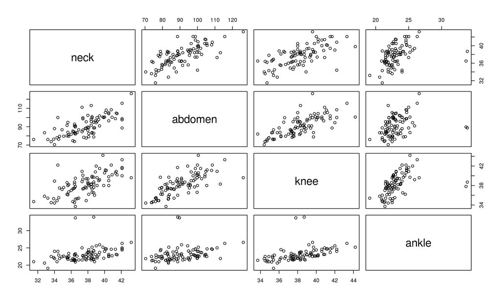

```r
plot(bfat)
```

```r
# Can see an outlier in the ankle variable
# Let's sort the ankle data to identify the outliers
sort(bfat[, "ankle"])
```

```
##  [1] 19.1 20.6 20.9 21.0 21.0 21.0 21.3 21.4 21.4 21.4 21.5 21.5 21.5 21.5 21.6
## [16] 21.6 21.7 21.7 21.8 21.8 21.9 21.9 21.9 21.9 22.0 22.0 22.0 22.1 22.1 22.1
## [31] 22.2 22.4 22.4 22.4 22.5 22.5 22.5 22.5 22.5 22.6 22.6 22.6 22.7 22.7 22.7
## [46] 22.7 22.8 22.9 22.9 22.9 22.9 23.0 23.0 23.1 23.1 23.1 23.1 23.2 23.3 23.4
## [61] 23.4 23.6 23.7 23.7 23.8 23.8 24.0 24.0 24.0 24.1 24.2 24.4 24.5 24.6 24.6
## [76] 24.7 24.7 24.7 25.0 25.0 25.2 25.2 25.6 25.9 26.3 26.6 33.7 33.9
```

```r
# Now we isolate the outliers
outlier_indices <-
  as.integer(rownames(bfat[which(bfat[, "ankle"] > 30), ]))
bfat[outlier_indices,]
```

```
##    neck abdomen knee ankle
## 31 38.7    88.7 38.7  33.9
## 84 36.5    89.7 37.8  33.7
```

There are 2 major outliers. These occur in the `ankle` variable.  
Specifically, the cases 31 and 84, as shown above.

```r
# Compute PCA
pca <- prcomp(bfat, scale = TRUE)
pca
```

```
## Standard deviations (1, .., p=4):
## [1] 1.6283179 0.8731395 0.5867784 0.4918329
##
## Rotation (n x k) = (4 x 4):
##               PC1         PC2         PC3        PC4
## neck    0.5283837  0.21938447  0.76758486  0.2889543
## abdomen 0.5351101  0.35203936 -0.18875359 -0.7443773
## knee    0.5460990  0.05660109 -0.60799295  0.5735126
## ankle   0.3691120 -0.90814925  0.07436491 -0.1830058
```

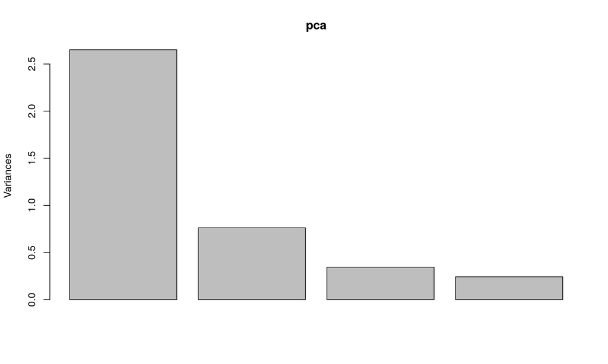

```r
plot(pca)
```

```r
# Compute summary
pca_summary <- summary(pca)
importances <- pca_summary[["importance"]]
importances
```

```
##                             PC1       PC2       PC3       PC4
## Standard deviation     1.628318 0.8731395 0.5867784 0.4918329
## Proportion of Variance 0.662850 0.1905900 0.0860800 0.0604700
## Cumulative Proportion  0.662850 0.8534500 0.9395300 1.0000000
```

```r
# Calculate percentage of variabilty of PC1, PC1+PC2
importances["Proportion of Variance", "PC1"]
```

```
## [1] 0.66285
```

```r
importances["Cumulative Proportion", 2]
```

```
## [1] 0.85345
```

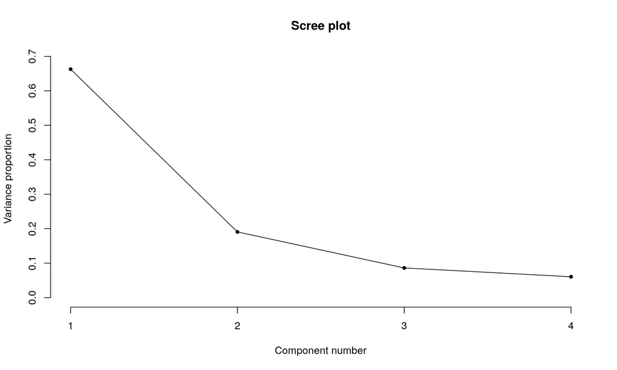

```r
# Show scree diagram
screeplot(pca)
```

We can that 66.285% of the variability in the dataset is accounted for by the first component.  
Furthermore, 85.345% of the variability in the dataset is accounted for by the first and second components combined.  
This can be seen graphically in the screeplot.  
Furthermore the screeplot illustrates how the most significant proportion of the variances is contributed by the first principal component.  
After this, the second, third and fourth principal components’ propertions decrease dramatically in order, as expected.  
The graph levels off significantly in the second component (however itstill may be significant), but levels off almost entirely for the subsequent components.

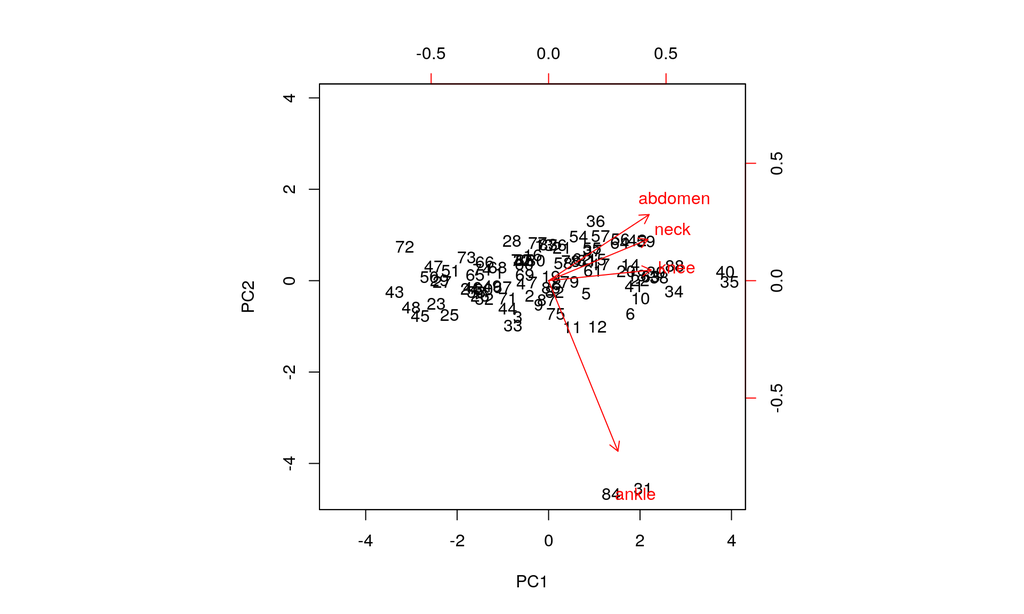

```r
# Graph the biplot with indices
biplot(pca, scale = 0)
```

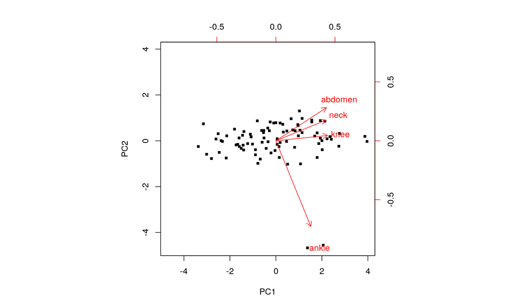

```r
# And repeat without indices
biplot(pca,
       scale = 0,
       xlabs = rep(".", nrow(bfat)),
       cex = c(3, 1))
```

```r
# Make a new dataframe including row totals
bfat_wtotal <- bfat
bfat_wtotal$total <- rowSums(bfat)
# Lowest totals
head(bfat_wtotal[order(bfat_wtotal$total),])
```

```
##    neck abdomen knee ankle total
## 48 34.0    70.4 34.4  21.9 160.7
## 43 31.5    76.0 34.7  21.0 163.2
## 72 33.2    76.0 35.4  19.1 163.7
## 45 33.6    73.7 34.5  22.5 164.3
## 29 36.4    73.9 34.5  21.3 166.1
## 27 36.2    74.6 34.7  21.4 166.9
```

```r
# Highest totals
head(bfat_wtotal[order(bfat_wtotal$total, decreasing = TRUE),])
```

```
##    neck abdomen knee ankle total
## 40 43.2   126.2 39.6  26.6 235.6
## 35 42.1   115.6 43.3  26.3 227.3
## 88 40.8   108.5 42.2  24.6 216.1
## 41 37.3   111.2 40.9  25.0 214.4
## 39 40.2   108.1 41.1  24.7 214.1
## 36 38.4   113.1 38.3  21.9 211.7
```

The first principal component appears to measure the total of the individual variables in each observation.  
In this case, the PC has positive weights on every variable - however has a slightly smaller weight on the `ankle` variable.

The second principal component appears to measure the total of the `abdomen`, `neck` and to a lesser degree, `knee` variables, with a strong negative weight to the `ankle` variable. It is, however, less significant than the first component.  
In this second component, upper body measurements (`neck` and `abdomen`) can be seen to have relatively large weights.  
The `knee` measurements are also positive to a slightly smaller extent.  
The `ankle` measurements weight for the second component is, however, significantly different in the second component.

There are clearly two outliers here, located on the bottom-right hand side on the biplot.  
These are most likely due to the two outliers identified earlier in part (a) in the ankle data.  
Observations in the upper right quadrant are high in both PC1 and PC2. This means they’ve recorded higher measurements for `abdomen`, `neck` and `knee`, but lower in `ankle`.  
Observations in the lower right quadrant are high in PC1 and low in PC2. This means they’ve recorded higher measurements for all variables.  
Observations in the upper left quadrant are low in PC1 and high in PC2. This means they’ve recorded lower measurements for all variables.  
Observations in the lower left are low in both PC1 and PC2. This means they’ve recorded higher measurements for the `ankle` variable, but lower measurements for the three remaining variables.  
Here, we can see that the arrows for `abdomen`, `neck` and `knee` are quite close to each other, which would indicate the correlation of these three variables.

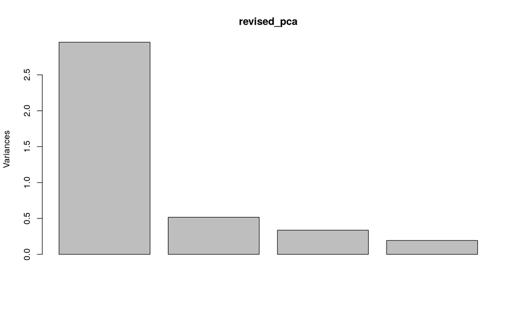

```r
# Compute PCA
revised_pca <- prcomp(bfat[-outlier_indices, ], scale = TRUE)
plot(revised_pca)
```

```r
# Compute summary
revised_pca_summary <- summary(revised_pca)
revised_importances <- revised_pca_summary[["importance"]]
revised_importances
```

```
##                             PC1       PC2       PC3       PC4
## Standard deviation     1.718635 0.7186065 0.5801971 0.4396245
## Proportion of Variance 0.738430 0.1291000 0.0841600 0.0483200
## Cumulative Proportion  0.738430 0.8675300 0.9516800 1.0000000
```

```r
# Calculate percentage of variabilty of PC1, PC1+PC2
revised_importances["Proportion of Variance", "PC1"]
```

```
## [1] 0.73843
```

```r
revised_importances["Cumulative Proportion", 2]
```

```
## [1] 0.86753
```

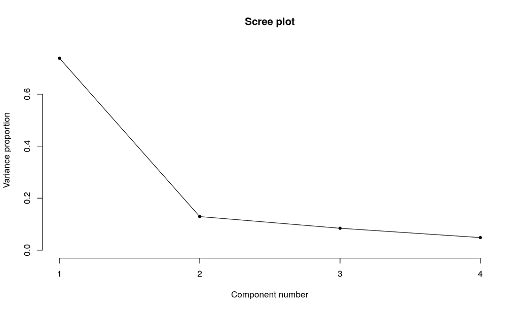

```r
# Show scree diagram
screeplot(revised_pca)
```

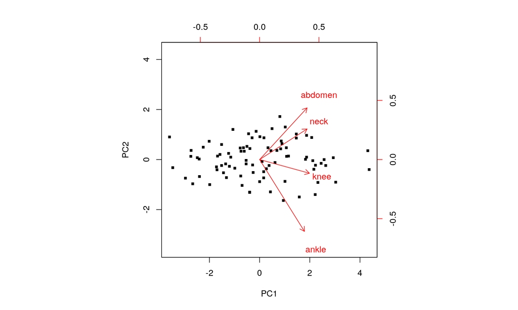

```r
# Show biplot
biplot(
  revised_pca,
  scale = 0,
  xlabs = rep(".", nrow(bfat[-outlier_indices, ])),
  cex = c(3, 1)
)
```

There do not appear to be any visible outliers in the revised biplot, having removed the previously observed outliers from our original data.